# Jupyter Notebook presentation

### Robert Beck, 03/14/2018

## Integrated environment for all phases of research

- Text: project description, notes, references, conclusions
- Equations via LaTeX, tables
- Data processing
- Computations
- Visualization
- Straightforward to convert into research paper
- Easy to save, share and reproduce work
- Growing popularity

## Architecture

[figure not shown]

- Local or remote notebook server
- Purely web interface, accessible from any browser
  - Password/token authentication
- Supports a wide variety of kernels to perform computations
  - Python, R
  - Matlab/Octave
  - IDL
  - Mathematica
  - C/C++, Fortran
  - C#, Java
  - Haskell
- Notebook file (.ipynb) containing all text/code/images
  - Can be exported to pdf/html for sharing

## "Standard" setup - Python

- Numpy/Pandas/Python for datafile manipulation
- Numpy/Scipy for scientific computation
- Matplotlib for visualization

## Installation

[figure not shown]

https://www.anaconda.com/download/ for Win/Linux/Mac, Python+Jupyter+common packages

Alternative with existing Python installation: $pip install jupyter

### Additional packages

$conda install package_name

$pip install package_name

### Running the server

$jupyter notebook

### Connecting to it from a browser

http://localhost:8888 for a standard local server, otherwise address:port

Provide password/token, access directory tree and start running notebooks

**Files are only accessible in the subdirectories of where the notebook server was started!**

## Notebook structure

- Made up of cells
  - Markdown cells contain formatted text, images, tables
  - Code cells contain code, runnable in the given language kernel
- Read-evaluate-print loop (REPL), i.e. interactive shell ran piecewise
  - Output of variables, figures, etc.

## Markdown examples

It is *generally* possible **to use** Markdown and HTML language *features* in Markdown cells, such as *italic*, **bold** or *both*.

- We already saw
- dotted lists
1. We also have
2. unsurprisingly
3. numbered lists

# There

## Are

### Different

#### Levels

##### Of highlighted headers

When you need to include equations, you can do it inline to say $E=mc^2$ or $d\tau=dt \, / \, a\left(t\right)$ in LaTeX. Or you can have them longer and centered:

$$ \frac{\Delta T}{T} = - \frac{2}{c^2} \int_{\tau_0}^{\tau_{z=9}} d\tau \frac{\partial\Phi\left(\vec{r}(\tau),\tau\right)}{\partial\tau}$$

$$\frac{\partial\Phi\left(\vec{k},\tau\right)}{\partial\tau} = a \dot{\Phi} = a \frac{3}{2}\left(\frac{H_0}{k}\right)^2 \Omega_m \frac{1}{a} \left[\frac{\dot{a}}{a} \delta\left(\vec{k},t\right)\left( 1-\beta(t)\right)\right] =\frac{3}{2}\left(\frac{H_0}{k}\right)^2 \Omega_m \left[\frac{\dot{a}}{a} \delta\left(\vec{k},t\right)\left( 1-\beta(t)\right)\right] $$

Tables are also possible, although it is usually better to print such structures from code.

| First Header | Second Header |
| --- | --- |
| Content Cell | Content Cell |
| Content Cell | Content Cell |

Sample code (unrunnable) can also be put here, even with syntax highlighting for a given language:

```
x=np.linspace(-pi,pi,1000)
y=list(cos(x))
```

> There are even response-like indentations. C code below.

> ```
> double x=0.0;
> for (int i=0; i<5; ++i){
>    x+=sqrt(i);
> }
> ```

> > There can be more levels of indentations.

## Code example

This short line will import the most common numpy and matplotlib modules into the namespace for convenience. Numpy is np, matplotlib is plt.

```python
%pylab inline
```

```python
a=5+2
a
```

```
7
```

```python
[x**2 for x in range(a)]
```

```
[0, 1, 4, 9, 16, 25, 36]
```

You can write and execute Python code in such fields. Objects/variables will stay in memory as long as the kernel isn't stopped/doesn't crash. (That is, unless they are explicitly deleted, or have no more references to them and are garbage collected.)

The documentation of a function can be opened within the notebook with the ? symbol:

```python
?np.random.normal
```

```python
np.random.normal(loc=0.0,scale=1.0,size=5)
```

```
array([-0.69235222, -0.64815002, -0.04646459, -1.39560659, -1.08325209])
```

```python
sample=np.random.normal(loc=0.0,scale=1.0,size=1000)
```

```python
sample
```

[output not shown]

[output cut: 279 more lines]

[output not shown]

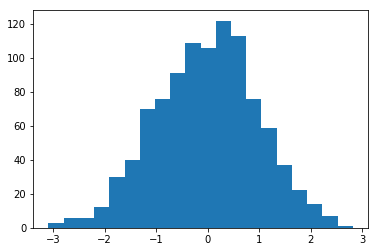

```python
plt.hist(sample, bins=20)
```

Compare: only last returned value is printed, if any, but ";" ends the statement so the histogram is not printed

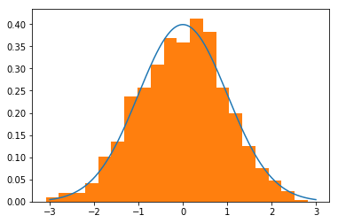

```python
from scipy.stats import norm

xSample=np.linspace(-3,3,200)

plt.plot(xSample,norm.pdf(xSample))
plt.hist(sample, bins=20, normed=True);
```

## Access to shell commands

```python
!ls -l
```

```
total 2744
drwxrwxrwx 0 root root    4096 Mar 14 00:29 data
drwxrwxrwx 0 root root    4096 Mar 14 15:36 fig
-rwxrwxrwx 1 root root 2806103 Mar 14 16:22 Jupyter Presentation.ipynb
```

```python
!mkdir TEST
```

```python
!ls -l
```

```
total 2744
drwxrwxrwx 0 root root    4096 Mar 14 00:29 data
drwxrwxrwx 0 root root    4096 Mar 14 15:36 fig
-rwxrwxrwx 1 root root 2806103 Mar 14 16:22 Jupyter Presentation.ipynb
drwxrwxrwx 0 root root    4096 Mar 14 16:23 TEST
```

```python
!rm -r TEST
```

```python
!ls -l
```

```
total 2744
drwxrwxrwx 0 root root    4096 Mar 14 00:29 data
drwxrwxrwx 0 root root    4096 Mar 14 15:36 fig
-rwxrwxrwx 1 root root 2806103 Mar 14 16:22 Jupyter Presentation.ipynb
```

```python
!cat data/LLR.py | head -10
```

[output not shown]

## Cell magic - special cell functionality

Write contents of cell into file:

```python
%%writefile data/hello.py

importVar=3.14
print('Hello World!')
```

```
Overwriting data/hello.py
```

Execute contents of file:

```python
%run data/hello.py
```

```
Hello World!
```

```python
print('Happy '+str(importVar)+ ' day Everyone!')
```

```
Happy 3.14 day Everyone!
```

Show contents of file in popup window:

```python
%pycat data/LLR.py
```

Load text file into code cell:

```python
 # %load data/LLR.py
import math
import numpy as np
from sklearn.neighbors import KNeighborsRegressor

def localLinearRegression(trainingCoordinates, trainingResponses, testCoordinates, neighborNumber, trainingWeights=None):

    sampleNumber = testCoordinates.shape[0]
    dim=testCoordinates.shape[1]

    if trainingWeights is None:
        trainingWeights=np.ones(trainingCoordinates.shape[0])

    testResponses = np.zeros(sampleNumber)

    knnreg = KNeighborsRegressor(n_neighbors=neighborNumber, weights='uniform', algorithm='kd_tree', leaf_size=40, p=2)
    knnreg.fit(trainingCoordinates, trainingResponses)

    for sample in range(0, sampleNumber):
        # find kNN

        [dist, ni] = knnreg.kneighbors(testCoordinates[sample,:].reshape(1,-1), neighborNumber)

        X=np.concatenate((np.ones(neighborNumber).reshape(-1,1),trainingCoordinates[ni.squeeze(),:]),axis=1)
        y=trainingResponses[ni.squeeze()]
        w=np.diag(trainingWeights[ni.squeeze()])


        rhs=np.zeros(dim+1)

        rhs=y.dot(w.dot(X))
        #for m in range(0, dim+1):
        #    for k in range(0,neighborNumber):
        #        rhs[m]+=X[k,m]*y[k]*w[k]

        lhs=np.zeros((dim+1,dim+1))

        lhs=(X.T).dot(w.dot(X))
        #for m in range(0,dim+1):
        #    for n in range(0,dim+1):
        #        for k in range(0,neighborNumber):
        #            lhs[m,n]+=X[k,m]*X[k,n]*w[k]

        try:
            coefficients = np.linalg.solve(lhs, rhs)
        except:
            break

        testResponses[sample]=(np.concatenate((np.ones(1),testCoordinates[sample,:]),axis=0).reshape(1,-1)).dot(coefficients.reshape(-1,1))

    return testResponses,coefficients,ni
```

Various other options: run the cell as shell/bash script, HTML/Javascript, etc.

Complete list here: http://ipython.readthedocs.io/en/stable/interactive/magics.html

There are even extensions (wrappers) for other languages via %load_ext

- R, Cython, Octave, Fortran

Additional tips and tricks: https://www.dataquest.io/blog/jupyter-notebook-tips-tricks-shortcuts/

## Hide code fields when presenting work

JavaScript trickery, can be refined

```python
from IPython.display import HTML

HTML('''<script>
code_show=true;
function code_toggle() {
 if (code_show){
 $('div.input').show();
 } else {
 $('div.input').hide();
 }
 code_show = !code_show
}
$( document ).ready(code_toggle);
</script>
<form action="javascript:code_toggle()"><input type="submit" value="Click here to toggle on/off the raw code."></form>''')
```

## Figures with matplotlib

```python
from scipy import integrate

sims=['BR','LCDM','EdS']
simColors=['blue','red','green']
simLabels=['AvERA','$\\Lambda$CDM','EdS']

times=[]
scaleFactors=[]
hubbleFactors=[]

snapshotNames=[]

for sim in sims:
    globalSimParams=np.genfromtxt('data/timeCurve_'+sim+'.txt',dtype='str')

    times.append(np.array([float(f) for f in globalSimParams[:,0]]))
    scaleFactors.append(np.array([float(f) for f in globalSimParams[:,1]]))
    hubbleFactors.append(np.array([float(f) for f in globalSimParams[:,3]]))

    snapshotNames.append(globalSimParams[:,2])


taus=[]

for i in range(len(sims)):

    taus.append(3*times[i][0]/scaleFactors[i][0]+integrate.cumtrapz(1.0/scaleFactors[i],times[i],initial=0))
```

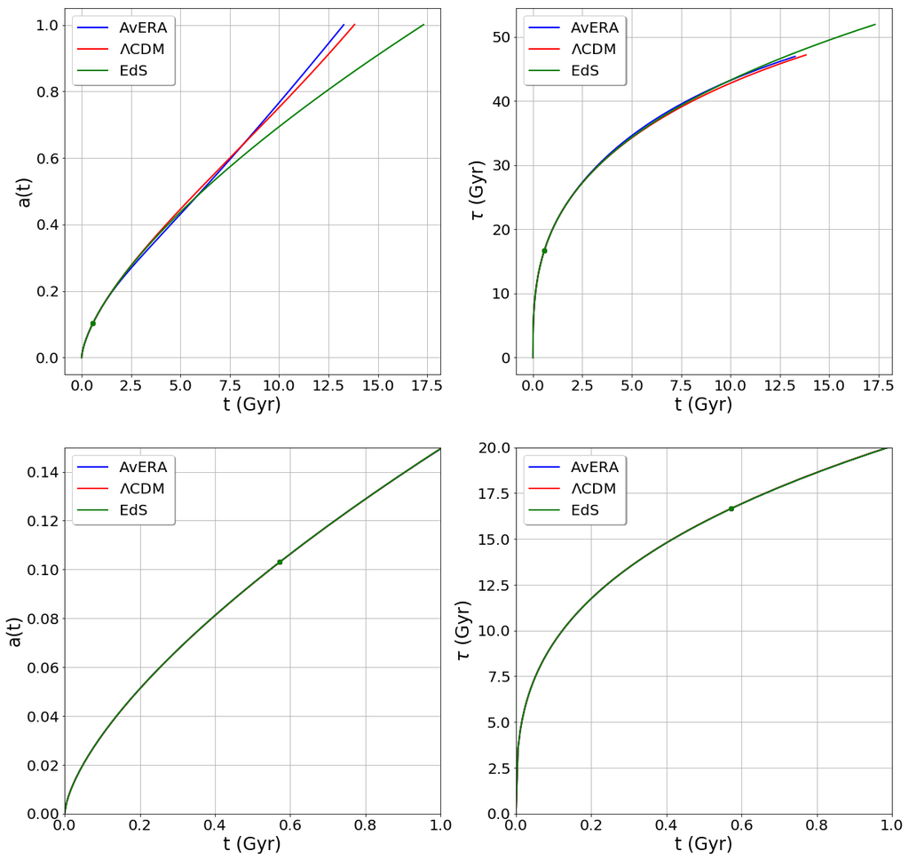

```python
fig = plt.figure(figsize=(20,20))



ax1 = fig.add_subplot(221)
ax3 = fig.add_subplot(223)
for i in range(len(sims)):
    tGridEdS=np.arange(0,times[i][0],times[i][0]/100)
    aGridEdS=tGridEdS**(2/3)*scaleFactors[i][0]/times[i][0]**(2/3)
    ax1.plot(tGridEdS,aGridEdS, color=simColors[i], lw=2)
    ax1.plot(times[i],scaleFactors[i], color=simColors[i], label=simLabels[i], lw=2)
    ax1.plot(times[i][0],scaleFactors[i][0], 'o', color=simColors[i])
    ax3.plot(tGridEdS,aGridEdS, color=simColors[i], lw=2)
    ax3.plot(times[i],scaleFactors[i], color=simColors[i], label=simLabels[i], lw=2)
    ax3.plot(times[i][0],scaleFactors[i][0], 'o', color=simColors[i])

ax1.set_xlabel('t (Gyr)', fontsize=24)
ax1.set_ylabel('a(t)', fontsize=24)
ax3.set_xlabel('t (Gyr)', fontsize=24)
ax3.set_ylabel('a(t)', fontsize=24)
ax3.set_xlim(0,1)
ax3.set_ylim(0,0.15)
ax1.grid(True)
ax1.tick_params(axis='both', labelsize=20)
ax3.grid(True)
ax3.tick_params(axis='both', labelsize=20)

ax2 = fig.add_subplot(222)
ax4 = fig.add_subplot(224)
for i in range(len(sims)):
    tGridEdS=np.arange(0,times[i][0],times[i][0]/100)
    tauGridEdS=3*tGridEdS**(1/3)/scaleFactors[i][0]*times[i][0]**(2/3)
    ax2.plot(tGridEdS,tauGridEdS, color=simColors[i], lw=2)
    ax2.plot(times[i],taus[i], color=simColors[i], label=simLabels[i], lw=2)
    ax2.plot(times[i][0],taus[i][0], 'o', color=simColors[i])
    ax4.plot(tGridEdS,tauGridEdS, color=simColors[i], lw=2)
    ax4.plot(times[i],taus[i], color=simColors[i], label=simLabels[i], lw=2)
    ax4.plot(times[i][0],taus[i][0], 'o', color=simColors[i])

ax2.set_xlabel('t (Gyr)', fontsize=24)
ax2.set_ylabel('$\\tau$ (Gyr)', fontsize=24)
ax4.set_xlabel('t (Gyr)', fontsize=24)
ax4.set_ylabel('$\\tau$ (Gyr)', fontsize=24)
ax4.set_xlim(0,1)
ax4.set_ylim(0,20)
ax2.grid(True)
ax2.tick_params(axis='both', labelsize=20)
ax4.grid(True)
ax4.tick_params(axis='both', labelsize=20)

ax1.legend(shadow=True, fancybox=True, fontsize=20, loc=2)
ax2.legend(shadow=True, fancybox=True, fontsize=20, loc=2)
ax3.legend(shadow=True, fancybox=True, fontsize=20, loc=2)
ax4.legend(shadow=True, fancybox=True, fontsize=20, loc=2)

plt.show()

fig.savefig('fig/cosmo.pdf')
```

## Interactive plotting

```python
pointNum=500
noise=0.4

xCoord=np.empty((pointNum,1))
xCoord[:,0]=np.arange(0,2.2*pi+1e-6,2.2*pi/(pointNum-1))

yCoord=sin(xCoord[:,0])+np.random.uniform(low=-1,high=1,size=len(xCoord))*noise
```

```python
def plotLinearRegression(xValues, yValues, xParam=0.0, kParam=50):

    #Plot the figure first
    fig = plt.figure(figsize=(20,16))
    ax1 = fig.add_subplot(111)

    ax1.set_xlabel('$x$', fontsize=40)
    ax1.set_ylabel('$y$', fontsize=40)
    ax1.tick_params(axis='both', labelsize=32, pad=14)

    ax1.set_ylim(-1.5,1.5)
    ax1.set_xlim(0,2.2*pi)

    points = ax1.plot(xCoord[:,0], yCoord, 'bo')

    #Do the linear regression

    xParam=np.array(xParam).reshape([1,1])

    [estimate, param, neighborIDs]=localLinearRegression(xValues,
                                                         yValues,
                                                         xParam,
                                                         kParam)

    xFit=xCoord
    yFit=param[0]+xFit*param[1]

    #Plot the estimates

    fitLine = ax1.plot(xFit, yFit, 'r-', linewidth=3)
    neighborPoints = ax1.plot(xValues[neighborIDs,0], yValues[neighborIDs], 'ro', linewidth=3, markersize=10)
    fitPoint = ax1.plot(xParam, estimate, 'ko', linewidth=3, markersize=15)

    return
```

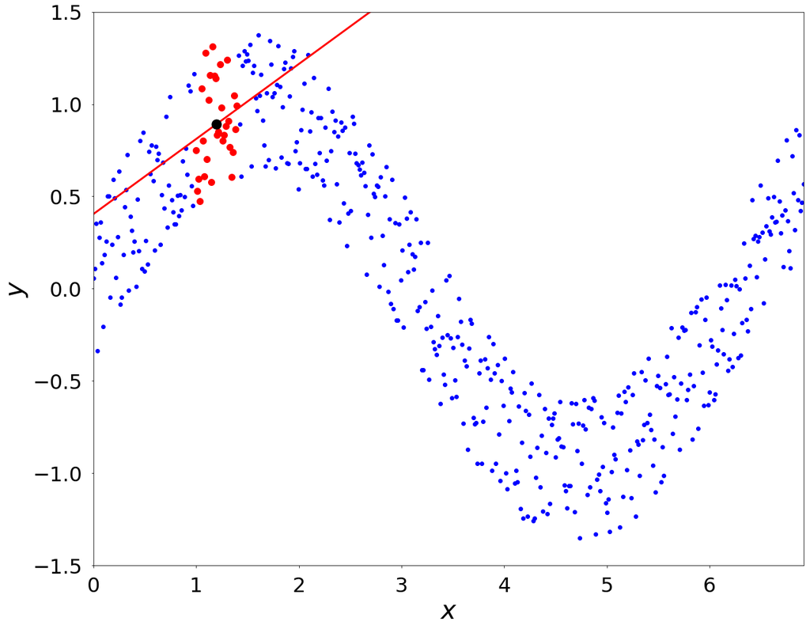

```python
plotLinearRegression(xCoord,yCoord, 1.2, 30)
```

```python
from ipywidgets import interact,fixed

interact(plotLinearRegression,
         xValues=fixed(xCoord),
         yValues=fixed(yCoord),
         xParam=(0.0,6.28,0.08),
         kParam=(2,500));
```

## Animated gif

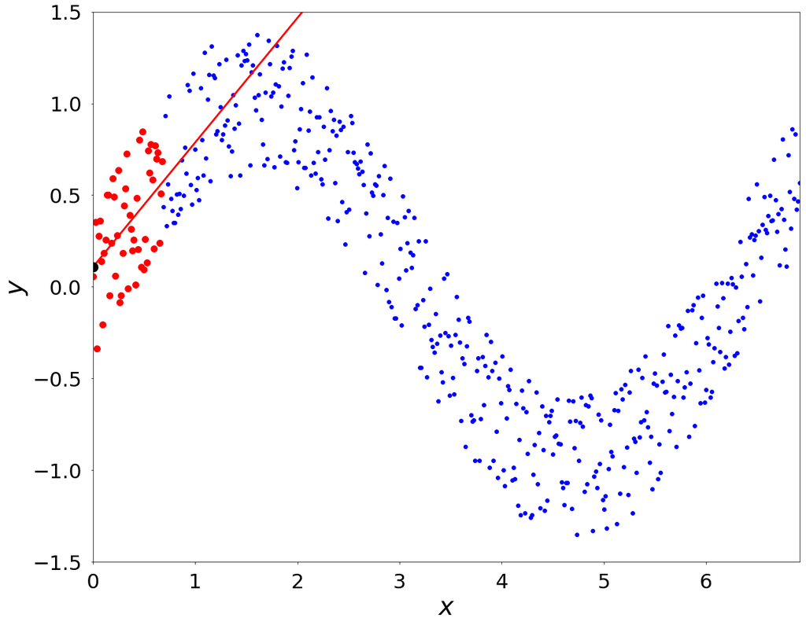

```python
from matplotlib.animation import FuncAnimation

frameNum=15

fig = plt.figure(figsize=(20,16))
ax1 = fig.add_subplot(111)

ax1.set_xlabel('$x$', fontsize=40)
ax1.set_ylabel('$y$', fontsize=40)
ax1.tick_params(axis='both', labelsize=32, pad=14)

ax1.set_ylim(-1.5,1.5)
ax1.set_xlim(0,2.2*pi)

i=0
points = ax1.plot(xCoord[:,0], yCoord, 'bo')

def update(i):

    test=np.empty((1,1))
    test[0,0]=i*2.2*pi/frameNum

    [estimate, param, neighborIDs] = localLinearRegression(xCoord, yCoord, test, 50)

    xs=np.arange(0,2.2*pi+1e-6,2.2*pi/(pointNum-1))
    ys=param[0]+xs*param[1]

    while (len(ax1.lines)>1):
        ax1.lines.pop()

    fitLine = ax1.plot(xs, ys, 'r-', linewidth=3)
    neighborPoints = ax1.plot(xCoord[neighborIDs,0], yCoord[neighborIDs], 'ro', linewidth=3, markersize=10)
    fitPoint = ax1.plot(test[0,0], estimate, 'ko', linewidth=3, markersize=15)

    return ax1

# FuncAnimation will call the 'update' function for each frame; here
# animating over frameNum frames, with an interval of 300ms between frames.
anim = FuncAnimation(fig, update, frames=range(frameNum), interval=300)


anim.save('fig/LLRimag.gif', dpi=80, writer='imagemagick')
```

## Extras - sound, video

```python
import scipy.io.wavfile
from IPython.display import Audio, display

[sps, data] = scipy.io.wavfile.read('data/imperial_march.wav')

display(Audio(data=data, rate=sps))
```

[interactive chart not shown]

```python
from IPython.display import YouTubeVideo
YouTubeVideo('LD-E3ZCjBho', width=800, height=600,loop=1)
```

[video not shown]

## Programming-debugging example

Say I want to find similar points (e.g. within 0.2 in x) that satisfy a criterion (e.g. 70% are well-measured)

```python
goodProbability=0.7
xSearchRange=0.2

goodPoints=np.random.uniform(size=len(xCoord))<goodProbability

similarIDs=[]

for i in range(len(xCoord)):

    closePointIDs=np.where(abs(xCoord-xCoord[i])<xSearchRange)

    #goodPoints[closePointIDs] -> these are the True/False (good/bad) values for each close object

    similarIDs.append(closePointIDs[goodPoints[closePointIDs]])
    #similarIDs.append(closePointIDs[0][goodPoints[closePointIDs[0]]])

similarIDs
```

```
---------------------------------------------------------------------------
IndexError                                Traceback (most recent call last)
<ipython-input-40-1ce16a221978> in <module>()
     12     #goodPoints[closePointIDs] -> these are the True/False (good/bad) values for each close object
     13
---> 14     similarIDs.append(closePointIDs[goodPoints[closePointIDs]])
     15     #similarIDs.append(closePointIDs[0][goodPoints[closePointIDs[0]]])
     16

IndexError: too many indices for array
```

I can access all variables at the time of the error, can copy out parts of code that seem problematic and see their output.

Bit more difficult when something goes wrong deep within a subfunction, but the input variables can be easily checked.

```python
closePointIDs[0]
```

```
array([ 0,  1,  2,  3,  4,  5,  6,  7,  8,  9, 10, 11, 12, 13, 14])
```

```python
xCoord.shape
```

```
(500, 1)
```

If used correctly, this enables very quick program development.

## Main points to remember about Jupyter

- Efficient way to do research
- Improves organization, reproducibility
- Collaboration facilitated by easy sharing
- Leverage Python to get the most results for minimal number of lines of code
  - Most algorithms are available in well-documented open-source packages

# Thanks for your attention!